Groupe: 4A IAD Groupe 1

Edouard NADAUD Guilhem NESPOULOUS Aymeric NOBLANC

Exercice : à rendre pour le dimanche 7 mars 2021 à 23h30 Simuler une série chronologique(Yt)t=1,…,100 suivant le modèle Yt = 0,01t + 1 + 2 sin(2πt/5) + εt , où(εt)t est un bruit blanc gaussien de variance 1/100.

```r
data=array()
erreur<-rnorm(100,sd=1/10,mean=0)
```

```r
for (i in 1:100){
  data[i]= (0.01*i)+1+(2*sin((2*pi*i)/5) )+ erreur[i]
}
```

On affiche notre serie temporelle

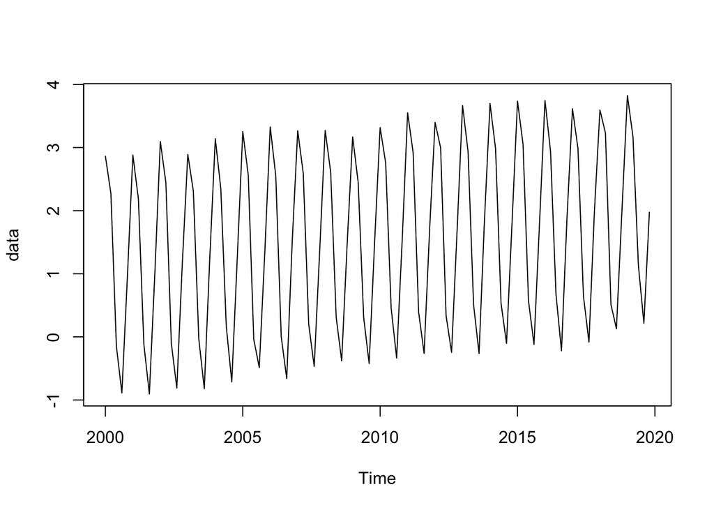

```r
data<-as.ts(data)
data<-ts(data,start=2000,frequency=5)
ts.plot(data)
```

Déterminer la tendance, la saisonnalité (période) de cette série chronologique. Les tracer.

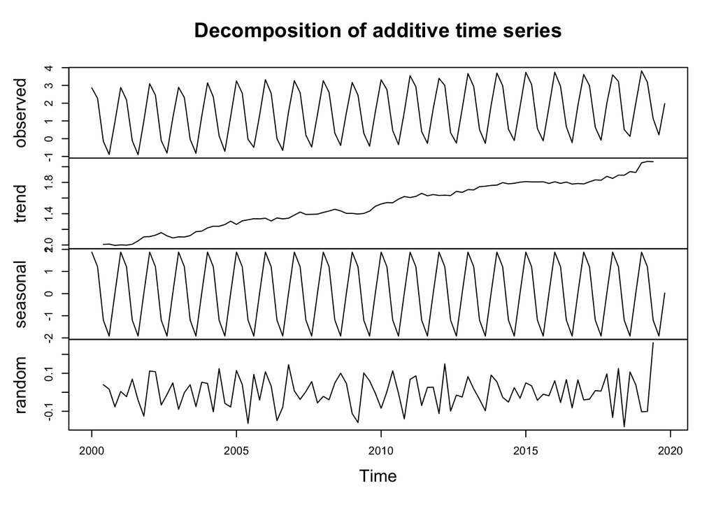

```r
data.dcp= decompose(data,type="add")
plot(data.dcp)
```

Notre serie temporelle est un modele aditif de forme

[output not shown]

Utiliser la méthode des moyennes mobiles ci-dessus pour éliminer la saisonnalité puis estimer les coefficients du saisonnier.

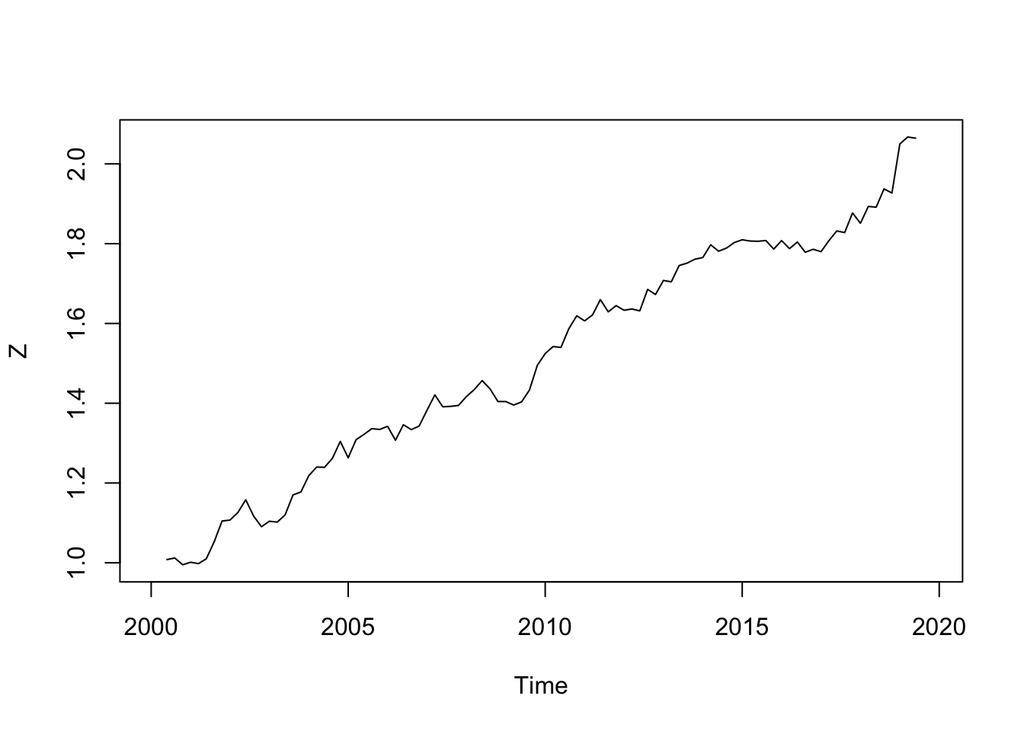

```r
filt<-rep(1/5,5)
Z<-filter(data,filter=filt,sides=2)
Z<-ts(Z,start=2000,frequency=5)
ts.plot(Z)
```

Estimation de la composante saisonnière S la saisonnalité

```r
S<-data-Z
```

Estimation c des coefficients du saisonnier Série corrigée des variations saisonnières Voici la saisonalité sur une periode 5

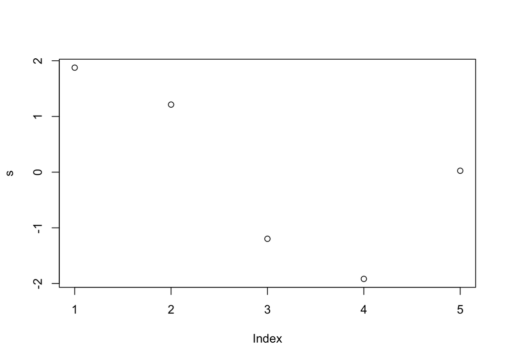

```r
s<-tapply(S,cycle(S),mean,na.rm=T)
s<-s-mean(s)
plot(s)
```

```r
CVS<-matrix(1,20,5)
```

Calcul de XCV S = X − S

Nous avons 5 données par an su 20 ans

```r
for (i in 1 :20) {
  for (j in 1 :5) {
    CVS[i,j]=t(matrix(data,5,20))[i,j]-s[j]
  }
}
```

```r
CVS=as.vector(t(CVS))
CVS=as.ts(CVS)
CVS=ts(CVS,start=2000,frequency=5)
```

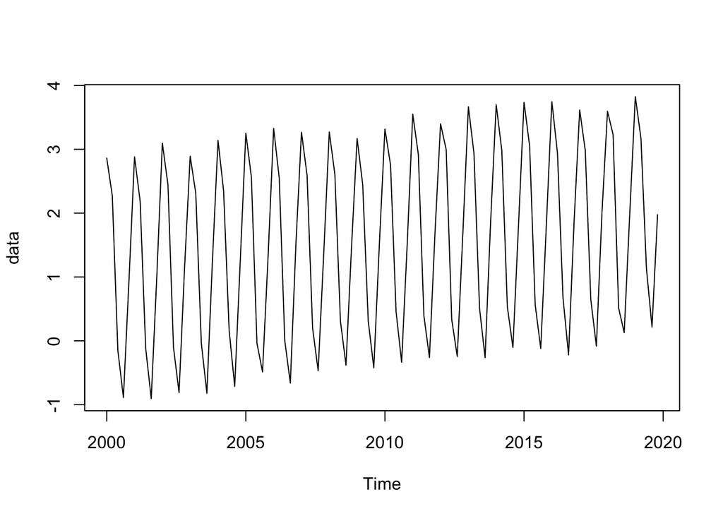

```r
ts.plot(data)
```

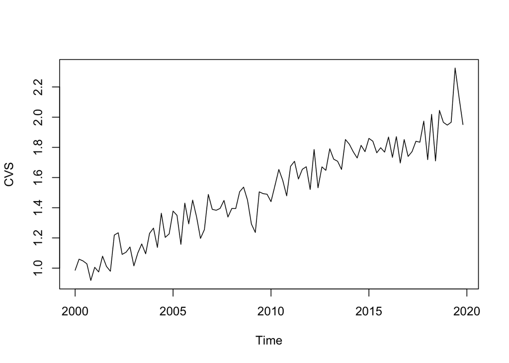

```r
ts.plot(CVS)
```

coefficient saisonnier

```r
s
```

```
##           1           2           3           4           5
##  1.87612091  1.21281802 -1.19676170 -1.91701991  0.02484268
```

Utiliser une régression linéaire par moindres carrés pour estimer les coefficients de la tendance.

```r
y=time(CVS)
CVS.lm=lm(CVS~y)
CVS.lm$coefficient
```

```
##   (Intercept)             y
## -102.97832740    0.05198707
```

Comparer les estimateurs avec les vrais coefficients.

yreel=0.01 ycalculé=0.05

```r
for (i in 1 :5) {
  print(2*sin((2*pi*i)/5))
}
```

```
## [1] 1.902113
## [1] 1.175571
## [1] -1.175571
## [1] -1.902113
## [1] -4.898587e-16
```

Proposer une prévision à l’horizon 3.

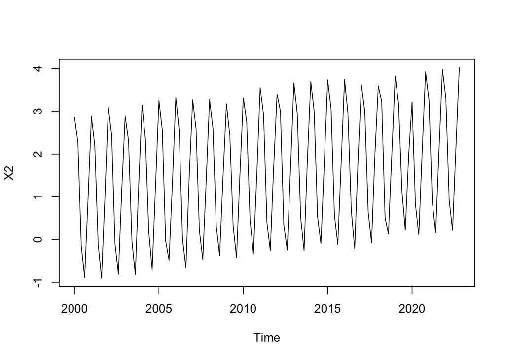

```r
X1=rep(1,15)
for (i in 1:15)
  {X1[i]=-102.44482083+0.05170816*(2020+5%%1+(i-1)/5) +s[i%%5+1]}

X2=c(as.vector(data),X1)

X2=as.ts(X2)
X2=ts(X2,start=2000,frequency=5)
plot(X2)
```

Analyser les résidus.Les représenter.

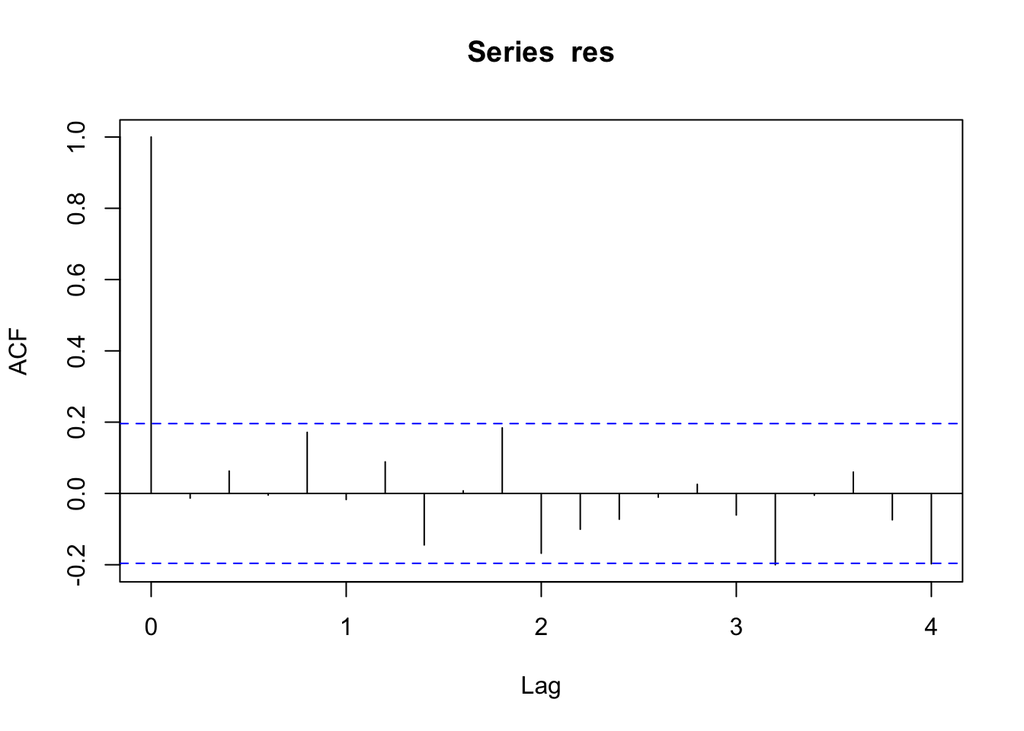

```r
res=CVS-CVS.lm$fitted.values
res=res/sqrt(var(res))
acf(res)
```

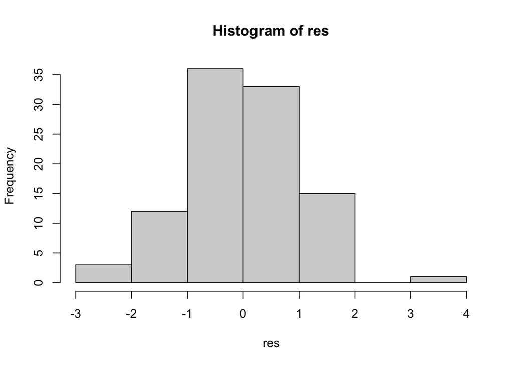

```r
hist(res)
```

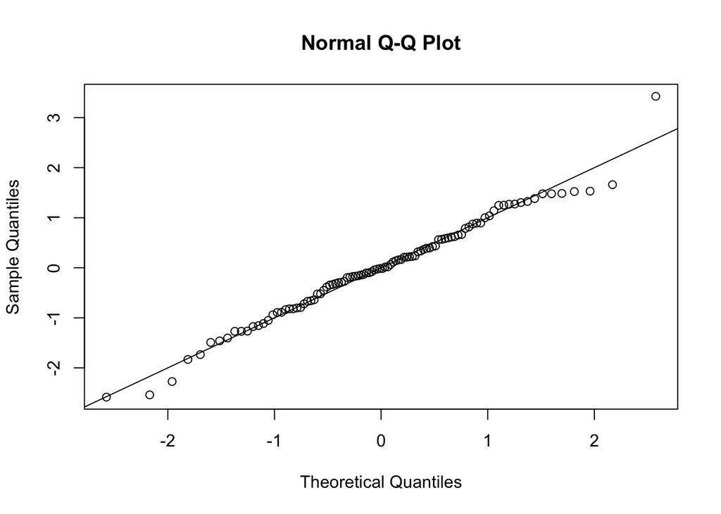

```r
qqnorm(res)
abline(0,1)
```

Appliquer la fonction decompose et comparer avec les vraies valeurs.

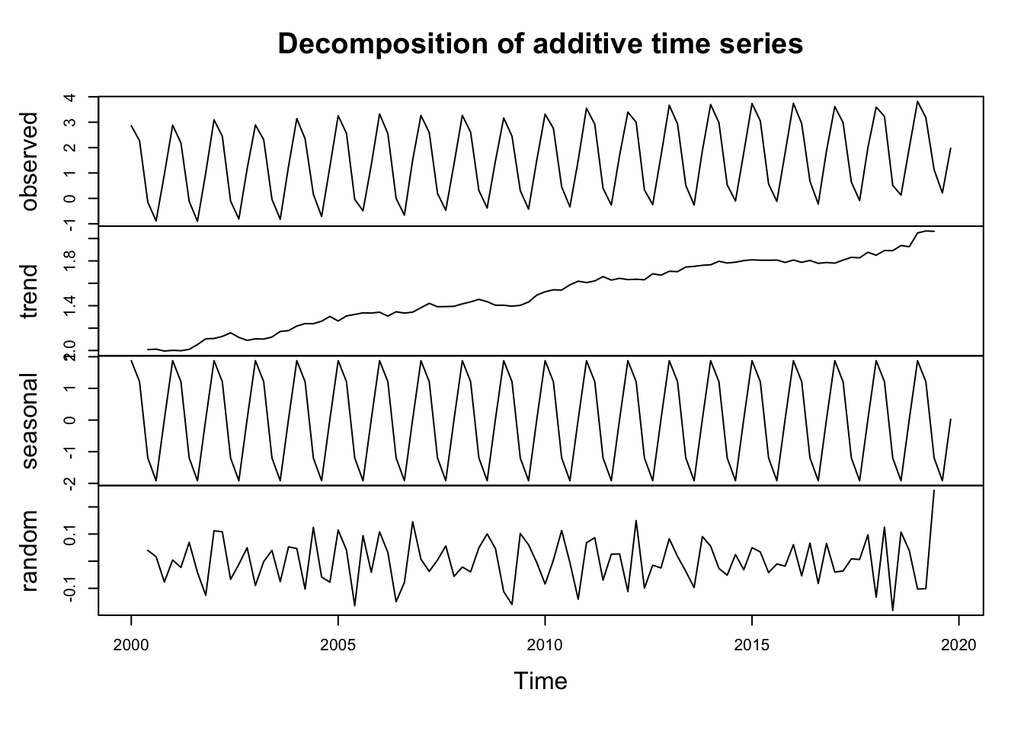

```r
data.dcp= decompose(data,type="add")
plot(data.dcp)
```

comparaison de la tendance decompose versus reel Nous pouvons remarqué que les valeurs réelle sont pratiquement identique aux valeurs estimée de decompose

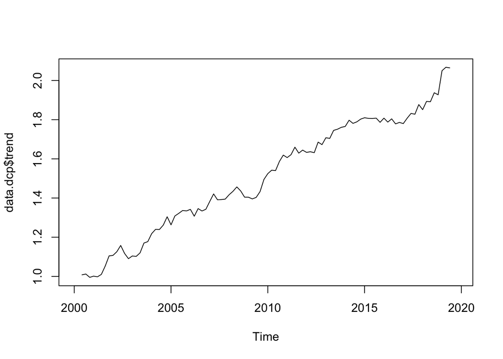

```r
plot(data.dcp$trend)
```

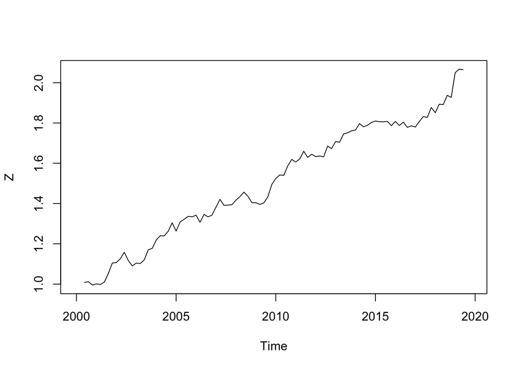

```r
plot(Z)
```

comparaison de la saisonalité decompose versus reel Nous pouvons remarqué que les valeurs réelle sont identique identique aux valeurs estimée de decompose

```r
if(sum(data.dcp$figure==s)==length(s)){
  print("les valeurs sont identique")
}
```

```
## [1] "les valeurs sont identique"
```

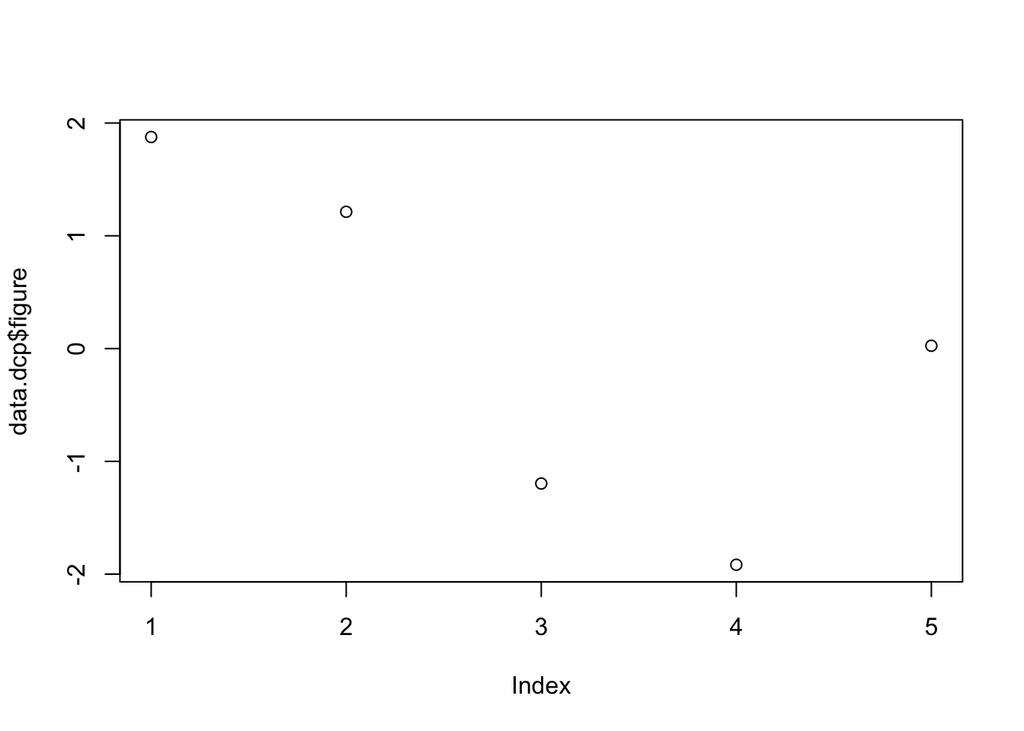

```r
plot(data.dcp$figure)
```

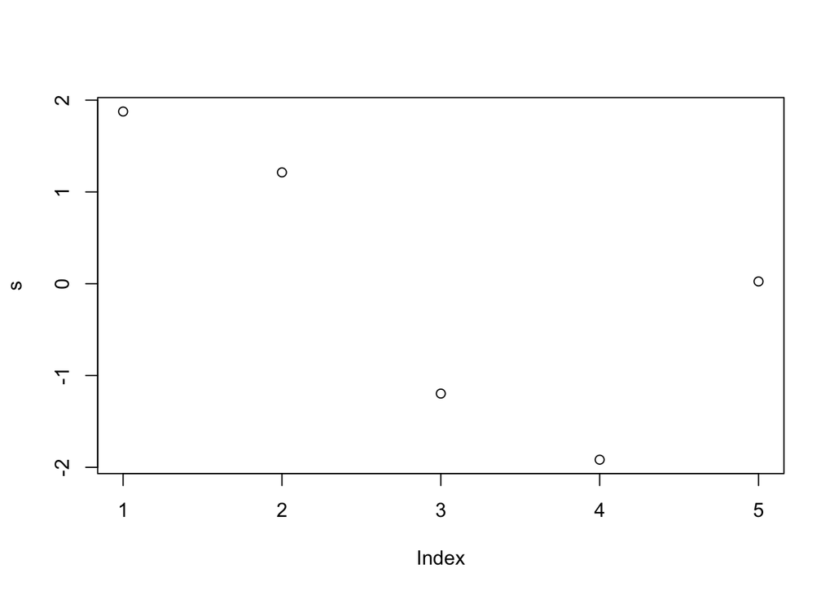

```r
plot(s)
```